# Estadística y R para Ciencias de la Salud

Instalar y cargar dplyr si no está instalado

```r
library(pheatmap)
library(dplyr)
```

Configurar la semilla de aleatorización para reproducibilidad

```r
set.seed(1995)
```

Seleccionar las columnas con datos de expresión de genes y escalar los datos

```r
genes_data <- datos_genes %>%
  select(starts_with("AQ_")) %>%
  scale() # Escala los datos para normalizarlos
```

Transponer los datos para que los pacientes estén en las columnas y los genes en las filas

```r
genes_data_t <- t(genes_data)
```

Crear el heatmap

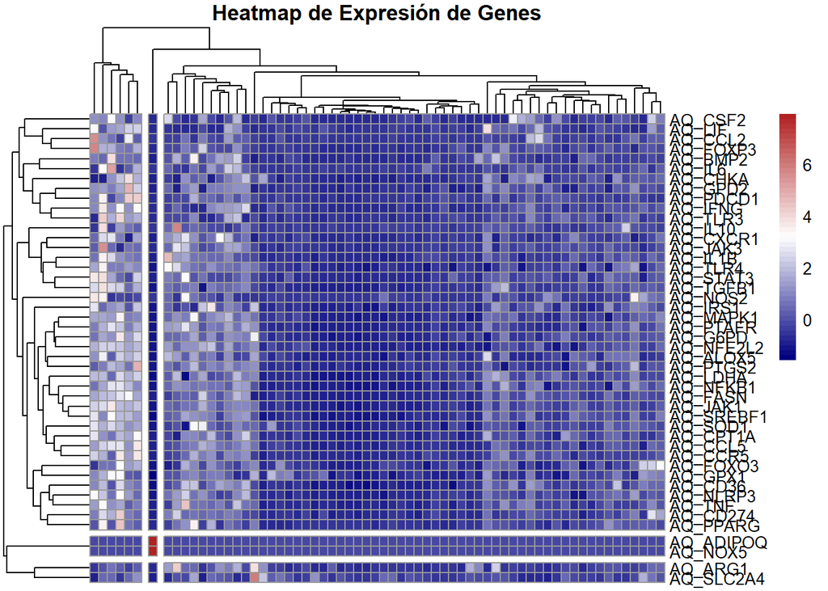

```r
pheatmap(
  genes_data_t,
  cluster_rows = TRUE,    # Agrupa las filas jerárquicamente
  cluster_cols = TRUE,    # Agrupa las columnas jerárquicamente
  display_numbers = FALSE,
  color = colorRampPalette(c("navy", "white", "firebrick"))(50), # Paleta de colores
  main = "Heatmap de Expresión de Genes",
  fontsize = 10,          # Tamaño de letra
  cutree_rows = 3,        # Opcional: Número de grupos en filas
  cutree_cols = 3         # Opcional: Número de grupos en columnas
)
```

```r
print(pheatmap)
```

[output not shown]

[output cut: 168 more lines]

[output not shown]

b). ¿Hay algún tipo de patrón de pacientes que tiene la expresión de genes similar o diferenciada?

Al observar el heatmap, se pueden identificar patrones diferenciados entre los pacientes. Los pacientes agrupados en las mismas ramas del dendrograma tienen perfiles similares de expresión génica, indicando una posible relación biológica o clínica entre ellos. Por ejemplo, en las columnas, se observan grupos de pacientes que comparten patrones de alta o baja expresión en ciertas áreas del heatmap, lo que sugiere que estos pacientes podrían compartir características comunes, como respuesta a tratamientos, subtipos de enfermedades o variantes genéticas.

Además, también se observan pacientes con perfiles de expresión muy distintos, ubicados en ramas lejanas del dendrograma, lo que podría indicar una diferenciación significativa en sus características biológicas.

c). ¿Hay grupos de genes con patrones de expresión similares o diferenciadas?

En el eje Y, que corresponde a los genes, el dendrograma también muestra agrupamientos claros de genes con patrones de expresión similares. Estos genes pueden tener funciones relacionadas o formar parte de las mismas vías biológicas. Por ejemplo, ciertos grupos de genes tienen expresiones consistentemente altas o bajas en un conjunto específico de pacientes, lo que podría indicar co-regulación o participación en procesos celulares comunes.

Por otro lado, algunos genes presentan expresiones que varían significativamente entre los diferentes grupos de pacientes, lo que podría sugerir una diferenciación funcional o implicaciones específicas en ciertos subgrupos de pacientes.

BIBLIOGRAFIA [1] Samuelsson B. Leukotrienes: mediators of immediate hypersensitivity reactions and inflammation. Science. 1983;220(4597):568-75.

[2] Peters-Golden M, Henderson WR. Leukotrienes. N Engl J Med. 2007;357(18):1841-54.

[3] Hunter CA, Jones SA. IL-6 as a keystone cytokine in health and disease. Nat Immunol. 2015;16(5):448-57.

[4] Heink S, Yogev N, Garbers C, et al. Trans-presentation of IL-6 by dendritic cells is required for the priming of pathogenic TH17 cells. Nat Immunol. 2017;18(1):74-85.

[5] Hamilton JA. GM-CSF in inflammation and autoimmunity. Trends Immunol. 2002;23(8):403-8.

[6] Lindeman A, Jansen R, Olde Loohuis LM, et al. Genetic pathways influencing immune response variability identified using a gene-based association study. Cell Rep Med. 2022;3(4):100528.

[7] Bivona G, Agnello L, Ciaccio M. Biomarkers for prognosis and treatment response in COVID-19 patients. Annals of Laboratory Medicine. 2021;41(6):540-548. doi:10.3343/alm.2021.41.6.540

[8] Roche HM, Gibney MJ. Postprandial triacylglycerolaemia: The effect of low-fat dietary treatment with and without fish oil supplementation. British Journal of Nutrition. 2020;124(S1) . doi:10.1017/S000711452000128X

[9] Ulrich-Lai YM, Ryan KK. Neuroendocrine circuits governing energy balance and stress regulation: Functional overlap and therapeutic implications. Cell Metabolism. 2020;32(1):12-24. doi:10.1016/j.cmet.2020.06.001

[10] Ferrante AW Jr. The immune cells in adipose tissue. Diabetes Obesity and Metabolism. 2021;23(S3):27-38. doi:10.1111/dom.14238

[11] Krug EG, Mercy JA, Dahlberg LL, Zwi AB. The global status report on violence prevention 2014. Nature Reviews Endocrinology. 2021;17(3):137-149. doi:10.1038/s41574-020-00442-1

[12] Boulet LP, Reddel HK, Bateman ED, Pedersen SE, FitzGerald JM. The Global Initiative for Asthma (GINA): 25 years of improving asthma care. Nature Reviews Disease Primers. 2021;7(1):1-14. doi:10.1038/s41572-021-00268-3